# Cook County Electricity Demand Time Series Modeling - SARIMAX

```r
library(forecast)
library(readr)
library(tseries)
library(ggplot2)
library(dplyr)
library(lubridate)
library(future.apply)
Sys.setlocale("LC_ALL", "en_US.UTF-8")
```

```
## [1] "LC_COLLATE=en_US.UTF-8;LC_CTYPE=en_US.UTF-8;LC_MONETARY=en_US.UTF-8;LC_NUMERIC=C;LC_TIME=en_US.UTF-8"
```

```r
# load data
df_1819 <- readRDS("data/train_test_split/df_1819.rds")
df_1819 <- df_1819[-1, ]
df_20   <- readRDS("data/train_test_split/df_20.rds")

cutoff <- ymd_hms("2020-01-01 00:00:00", tz="UTC")
```

### Covariate: Weather + Month dummy

```r
weather_path <- "data/raw/ORD_weather.csv"

df_weather <- read.csv(weather_path, stringsAsFactors = FALSE) %>%
  filter(valid != "valid") %>%
  mutate(
    timestamp = ymd_hm(valid, tz = "UTC"),
    tmpf = parse_number(tmpf),
    dwpf = parse_number(dwpf),
    sped = parse_number(sped),
    p01m = parse_number(p01m),
    ts_hour_utc = round_date(timestamp, "hour")
  )
head(df_weather,2)
```

```
##   station         valid tmpf dwpf  sped p01m           timestamp
## 1     ORD 2018/1/1 0:51    5   -6 12.65    0 2018-01-01 00:51:00
## 2     ORD 2018/1/1 1:51    4   -7 10.35    0 2018-01-01 01:51:00
##           ts_hour_utc
## 1 2018-01-01 01:00:00
## 2 2018-01-01 02:00:00
```

- station: air monitoring station.
- valid: utc timestamp as string
- tmpf: air temperature [F]
- dwpf: dew point [F], the temperature to which air must be cooled to become saturated with water vapor ( relative humidity)
- sped: wind speed [mph]
- p01m: 1 hour precipitation [mm]

**tidy up the weaather df to be aligned with elec demand df**

```r
# round to hour
df_weather_hr <- df_weather %>%
  group_by(ts_hour_utc) %>%
  summarise(
    across(c(tmpf, dwpf, sped, p01m),
           ~ mean(.x, na.rm = TRUE)),
    .groups = "drop"
  ) %>%
  arrange(ts_hour_utc)

# A complete hourly UTC time grid
full_hours <- tibble(
  ts_hour_utc = seq(min(df_weather_hr$ts_hour_utc),
                    max(df_weather_hr$ts_hour_utc),
                    by = "hour")
)

df_weather_full <- full_hours %>%
  left_join(df_weather_hr, by = "ts_hour_utc")

# Missing weather are linearly interpolated.
df_weather_full <- df_weather_full %>%
  arrange(ts_hour_utc) %>%
  mutate(t = as.numeric(ts_hour_utc)) %>%
  mutate(
    across(
      c(tmpf, dwpf, sped, p01m),
      ~ approx(t[!is.na(.x)],
               .x[!is.na(.x)],
               t,
               rule = 2)$y
    )
  ) %>%
  select(-t)
```

**Feature engineering on weather data**

```r
tmp_threshold <-50

df_weather_full <- df_weather_full %>%
  mutate(
    # time
    month = month(ts_hour_utc),

    # Heating Degree Hour & Cooling Degree Hour
    tmpf2 = (tmpf - tmp_threshold)^2,
    HDH   = pmax(tmp_threshold - tmpf, 0),
    HDH2  = HDH^2,
    CDH   = pmax(tmpf - tmp_threshold, 0),
    CDH2  = CDH^2,

    # season indicator
    is_winter = ifelse(month %in% c(12,1,2,3), 1, 0),
    is_summer = ifelse(month %in% c(6,7,8,9), 1, 0),

    # interaction
    winter_HDH  = HDH * is_winter,
    winter_wind = sped * is_winter,
    summer_CDH  = CDH * is_summer,
    summer_dew  = dwpf * is_summer
  )
```

**month dummy**

```r
df_weather_full$month_f <- factor(df_weather_full$month,
                                   levels = 1:12,
                                   labels = month.abb)
month_dummy <- model.matrix(~ month_f - 1, data = df_weather_full)

# drop one to avoid multilinearity
month_dummy <- month_dummy[, colnames(month_dummy) != "month_fJan", drop = FALSE]
```

**Final Xreg**

```r
df_xreg <- cbind(
  df_weather_full %>%
    select(ts_hour_utc, tmpf2, HDH, CDH, HDH2, CDH2, p01m, is_winter, is_summer, winter_HDH, winter_wind, summer_CDH, summer_dew) %>%
    rename(timestamp = ts_hour_utc),
  month_dummy
) %>%
  as.data.frame()

df_xreg_1819 <- df_xreg %>% filter(timestamp < cutoff)
df_xreg_20   <- df_xreg %>% filter(timestamp >= cutoff)
```

## Train - Validation - Test

### split train validation on 1819 data

```r
H_val <- 24 * 7 * 2  # 2 weeks

# 1) assure time sorting
df_1819      <- df_1819 %>% arrange(timestamp)
df_xreg_1819 <- df_xreg_1819 %>% arrange(timestamp)

# 2) Alignment check
stopifnot(nrow(df_1819) == nrow(df_xreg_1819))
stopifnot(all(df_1819$timestamp == df_xreg_1819$timestamp))

# 3) train/val index
n_1819 <- nrow(df_1819)
idx_train <- 1:(n_1819 - H_val)
idx_val   <- (n_1819 - H_val + 1):n_1819

y_train <- df_1819[idx_train, ]
y_val   <- df_1819[idx_val, ]

df_xreg_train <- df_xreg_1819[idx_train, ]
df_xreg_val   <- df_xreg_1819[idx_val, ]
```

**SARIMAX input dtype：ts + xreg matrix**

```r
y_col <- "electricity_demand"

# ts: hourly, frequency=24
y_train_ts <- ts(y_train[[y_col]], frequency = 24)
y_val_ts   <- ts(y_val[[y_col]],   frequency = 24)

# xreg: drop timestamp, as.matrix
xreg_train <- df_xreg_train %>% select(-timestamp) %>% as.matrix()
xreg_val   <- df_xreg_val   %>% select(-timestamp) %>% as.matrix()

stopifnot(length(y_train_ts) == nrow(xreg_train))
stopifnot(length(y_val_ts)   == nrow(xreg_val))
stopifnot(ncol(xreg_train)   == ncol(xreg_val))
stopifnot(all(colnames(xreg_train) == colnames(xreg_val)))
```

**plot to show xreg**

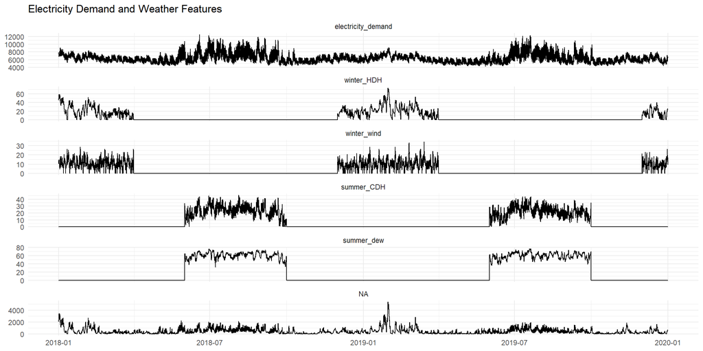

```r
library(tidyr)

y_col <- "electricity_demand"

plot_base <- df_1819 %>%
  select(timestamp, all_of(y_col)) %>%
  inner_join(
    df_xreg_1819 %>%
      select(timestamp, tmpf2, winter_HDH, winter_wind, summer_CDH, summer_dew),
    by = "timestamp"
  ) %>%
  arrange(timestamp)

plot_df <- plot_base %>%
  pivot_longer(
    cols = -timestamp,
    names_to = "series",
    values_to = "value"
  ) %>%
  mutate(
    series = factor(
      series,
      levels = c(
        y_col,
        "tmpf^2,",
        "winter_HDH",
        "winter_wind",
        "summer_CDH",
        "summer_dew"
      )
    )
  )

ggplot(plot_df, aes(x = timestamp, y = value)) +
  geom_line() +
  facet_wrap(~series, ncol = 1, scales = "free_y") +
  theme_minimal() +
  labs(
    title = "Electricity Demand and Weather Features",
    x = NULL,
    y = NULL
  )
```

**multicollinearity**

```r
weather_features <- df_xreg_train %>%
  select(winter_HDH, winter_wind, summer_CDH, summer_dew)

library(usdm)
vif(weather_features)
```

```
##     Variables      VIF
## 1  winter_HDH 1.837000
## 2 winter_wind 1.875769
## 3  summer_CDH 7.459759
## 4  summer_dew 7.747454
```

summer_CDH and summer_dew can not be used at the same time.

### Assumptions made for the modeling

(S)ARIMAX models require future values of exogenous covariates when generating forecasts. In this application, weather features such as temperature and precipitation are used as an external regressor. Since reliable weather forecasts are available and generally highly accurate over short horizons, we assume that future temperature forecasts are equal to the realized temperature values. Therefore, weather features are treated as known when producing demand forecasts.

We assume the covariate can solve the heteroscedasticity issue.

The weather data is actually the records from ord station in Chicago, here we assume the weather condition in Chicago and Cook County are identical.

### Train - Validation

#### Create func for validation

```r
plot_residual_diag <- function(fit, timestamp) {
  res <- residuals(fit)
  par(mfrow = c(2,2), mar = c(4,4,2,1))
  plot(timestamp, res, type="l"); abline(h=0,lty=2)
  hist(res, breaks=50, prob=TRUE); lines(density(res, na.rm=TRUE))
  acf(res, lag.max=24, na.action=na.pass, ylim=c(-0.2,0.2))
  pacf(res, lag.max=24, na.action=na.pass)
  par(mfrow=c(1,1))
}

plot_residual_acf_longlag <- function(fit) {
  res <- residuals(fit)
  par(mfrow=c(2,1), mar=c(4,4,2,1))
  acf(res, lag.max=24*7*4, na.action=na.pass, ylim=c(-0.2,0.2))
  abline(v=c(7,14,21,28), col="red", lty=3)
  pacf(res, lag.max=24*7*4, na.action=na.pass)
  abline(v=c(7,14,21,28), col="red", lty=3)
  par(mfrow=c(1,1))
}
```

```r
calc_metrics <- function(actual, forecast_mean) {
  actual <- as.numeric(actual)
  forecast_mean <- as.numeric(forecast_mean)

  c(
    RMSE = sqrt(mean((actual - forecast_mean)^2)),
    MAE  = mean(abs(actual - forecast_mean)),
    MAPE = mean(abs((actual - forecast_mean) / actual)) * 100
  )
}

plot_train_valid_forecast <- function(
  y_train,           # data.frame, must contain timestamp
  y_train_ts,        # ts or numeric (train actual values)
  y_val,             # data.frame, must contain timestamp
  y_val_ts,          # ts or numeric (validation actual values)
  fc_obj,            # forecast object from forecast()
  ci_level = 2,      # which column of lower/upper to use (e.g., 2 for 95%)
  lookback_days = 7*12  # how many days before split to show
) {
  # --- forecast & actual vector ---
  yhat_valid <- as.numeric(fc_obj$mean)
  y_valid_vec <- as.numeric(y_val_ts)

  # --- align length (safety) ---
  h <- length(yhat_valid)

  # timestamps for validation/forecast must be length h
  ts_val <- y_val$timestamp[seq_len(h)]

  # --- 1. train actual ---
  train_df <- data.frame(
    timestamp = y_train$timestamp,
    value     = as.numeric(y_train_ts),
    type      = "Train"
  )

  # --- 2. validation actual (aligned) ---
  valid_df <- data.frame(
    timestamp = ts_val,
    value     = y_valid_vec[seq_len(h)],
    type      = "Validation"
  )

  # --- 3. forecast df (aligned) ---
  forecast_df <- data.frame(
    timestamp = ts_val,
    Forecast  = yhat_valid,
    Lower     = fc_obj$lower[seq_len(h), ci_level],
    Upper     = fc_obj$upper[seq_len(h), ci_level]
  )

  split_time <- min(ts_val)

  # --- 4. plot ---
  ggplot2::ggplot() +
    ggplot2::geom_line(
      data = train_df,
      ggplot2::aes(x = timestamp, y = value),
      color = "black", linewidth = 0.6
    ) +
    ggplot2::geom_line(
      data = valid_df,
      ggplot2::aes(x = timestamp, y = value),
      color = "black", linewidth = 0.6
    ) +
    ggplot2::geom_ribbon(
      data = forecast_df,
      ggplot2::aes(x = timestamp, ymin = Lower, ymax = Upper),
      fill = "pink", alpha = 0.3
    ) +
    ggplot2::geom_line(
      data = forecast_df,
      ggplot2::aes(x = timestamp, y = Forecast),
      color = "red", linewidth = 0.7
    ) +
    ggplot2::geom_vline(
      xintercept = split_time,
      linetype = "dashed", color = "blue"
    ) +
    ggplot2::theme_minimal() +
    ggplot2::labs(
      title = "Train + Validation Forecast",
      x = "Time",
      y = "Electricity Demand"
    ) +
    ggplot2::coord_cartesian(
      xlim = c(
        split_time - lubridate::days(lookback_days),
        max(ts_val)
      )
    )
}
```

#### Try 1

```r
weather_vars_subset1 <- c("tmpf2")
Xreg_input <- xreg_train[, weather_vars_subset1, drop = FALSE]

fit_sarimax_D1_1 <- Arima(
  y_train_ts,
  xreg = Xreg_input,
  order = c(4,0,3),
  seasonal = list(order = c(2,1,1), period = 24),
  method = "ML",
)

summary(fit_sarimax_D1_1)
```

```
## Series: y_train_ts
## Regression with ARIMA(4,0,3)(2,1,1)[24] errors
##
## Coefficients:
##          ar1     ar2     ar3      ar4     ma1     ma2     ma3    sar1     sar2
##       0.3496  0.6531  0.4220  -0.4864  1.4616  1.0598  0.1648  0.1855  -0.0962
## s.e.  0.0486  0.0522  0.0333   0.0235  0.0486  0.0411  0.0150  0.0092   0.0084
##          sma1   tmpf2
##       -0.8351  0.1183
## s.e.   0.0048  0.0070
##
## sigma^2 = 4489:  log likelihood = -96506.33
## AIC=193036.7   AICc=193036.7   BIC=193129.7
##
## Training set error measures:
##                       ME     RMSE    MAE         MPE      MAPE       MASE
## Training set -0.06521161 66.93454 45.685 -0.01083022 0.6989155 0.09358461
##                      ACF1
## Training set 0.0009964858
```

**Check Residuals**

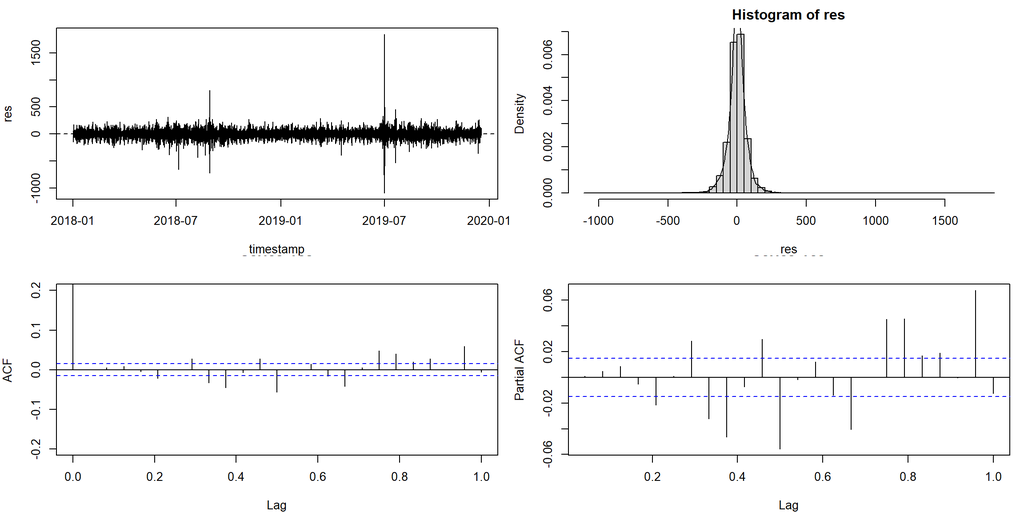

```r
plot_residual_diag(fit_sarimax_D1_1, y_train$timestamp)
```

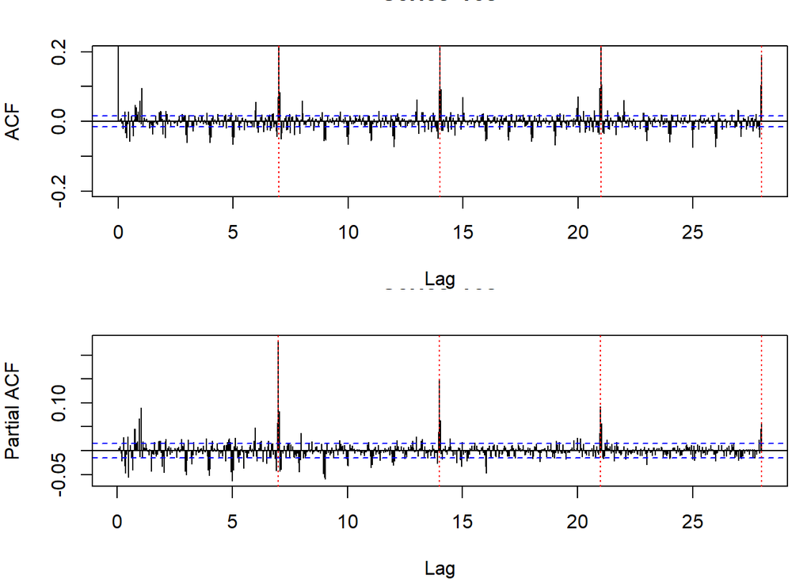

```r
plot_residual_acf_longlag(fit_sarimax_D1_1)
```

Obiviously that, acf and pacf all have significant weekly lags, indicating that seasonality = 168 should be considered.

This shows the limitation of SARIMAX can only have one seasonality.

**Validation**

```r
weather_vars <- weather_vars_subset1

xreg_val_subset <- xreg_val[, weather_vars, drop = FALSE]
fc_sarima_D1_1 <- forecast(fit_sarimax_D1_1, h = H_val, xreg = xreg_val_subset)
```

```r
calc_metrics(y_val_ts, fc_sarima_D1_1$mean)
```

```
##      RMSE       MAE      MAPE
## 867.13889 722.61800  12.90568
```

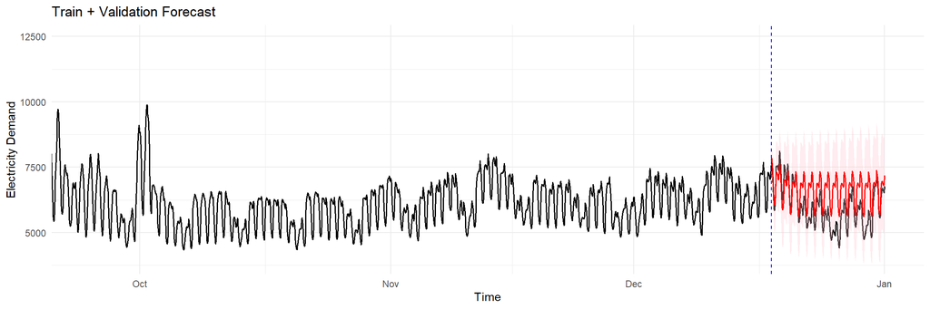

```r
plot_train_valid_forecast(
  y_train = y_train,
  y_train_ts = y_train_ts,
  y_val = y_val,
  y_val_ts = y_val_ts,
  fc_obj = fc_sarima_D1_1,
  ci_level = 2,
  lookback_days = 7*12
)
```

#### Try 2

```r
library(dplyr)

y_col <- "electricity_demand"
weather_vars_subset2 <- c("winter_HDH", "winter_wind", "CDH2", "p01m")

lm_df <- y_train %>%
  select(timestamp, y = all_of(y_col)) %>%
  left_join(
    df_xreg_train %>% select(timestamp, all_of(weather_vars_subset2)),
    by = "timestamp"
  )

fit_lm <- lm(
  y ~ winter_HDH + winter_wind + CDH2 + p01m,
  data = lm_df
)

summary(fit_lm)
```

```
##
## Call:
## lm(formula = y ~ winter_HDH + winter_wind + CDH2 + p01m, data = lm_df)
##
## Residuals:
##     Min      1Q  Median      3Q     Max
## -2847.2  -631.5     5.0   593.4  3753.5
##
## Coefficients:
##              Estimate Std. Error t value Pr(>|t|)
## (Intercept) 5.564e+03  9.098e+00 611.503  < 2e-16 ***
## winter_HDH  3.444e+01  6.708e-01  51.333  < 2e-16 ***
## winter_wind 2.716e+01  1.425e+00  19.065  < 2e-16 ***
## CDH2        3.023e+00  1.744e-02 173.266  < 2e-16 ***
## p01m        3.649e+01  7.848e+00   4.649 3.35e-06 ***
## ---
## Signif. codes:  0 '***' 0.001 '**' 0.01 '*' 0.05 '.' 0.1 ' ' 1
##
## Residual standard error: 778.7 on 17178 degrees of freedom
## Multiple R-squared:  0.6411, Adjusted R-squared:  0.6411
## F-statistic:  7673 on 4 and 17178 DF,  p-value: < 2.2e-16
```

```r
weather_vars_subset2 <- c("winter_HDH","CDH2", "p01m")
Xreg_input <- xreg_train[, weather_vars_subset2, drop = FALSE]

fit_sarimax_D1_2 <- Arima(
  y_train_ts,
  xreg = Xreg_input,
  order = c(4,0,3),
  seasonal = list(order = c(2,1,1), period = 24),
  method = "CSS-ML",
)

summary(fit_sarimax_D1_2)
```

```
## Series: y_train_ts
## Regression with ARIMA(4,0,3)(2,1,1)[24] errors
##
## Coefficients:
##          ar1     ar2     ar3      ar4     ma1     ma2     ma3    sar1     sar2
##       0.3595  0.6456  0.4144  -0.4802  1.4516  1.0514  0.1644  0.1850  -0.0956
## s.e.  0.0488  0.0521  0.0347   0.0243  0.0488  0.0419  0.0150  0.0091   0.0084
##          sma1  winter_HDH    CDH2    p01m
##       -0.8348      2.7866  0.1396  3.8623
## s.e.   0.0048      0.6209  0.0083  0.5095
##
## sigma^2 = 4476:  log likelihood = -96479.64
## AIC=192987.3   AICc=192987.3   BIC=193095.8
##
## Training set error measures:
##                       ME     RMSE      MAE         MPE     MAPE       MASE
## Training set -0.08116656 66.83065 45.63499 -0.01095963 0.698001 0.09348216
##                      ACF1
## Training set 0.0007484042
```

**Validation**

```r
weather_vars <- weather_vars_subset2

xreg_val_subset <- xreg_val[, weather_vars, drop = FALSE]
fc_sarima_D1_2 <- forecast(fit_sarimax_D1_2, h = H_val, xreg = xreg_val_subset)
```

```r
calc_metrics(y_val_ts, fc_sarima_D1_2$mean)
```

```
##      RMSE       MAE      MAPE
## 878.43190 736.06594  13.13999
```

#### Try 3

```r
weather_vars_subset3 <- c("tmpf2", "p01m")
Xreg_input <- xreg_train[, weather_vars_subset3, drop = FALSE]

fit_sarimax_D1_3 <- auto.arima(
  y_train_ts,
  xreg = Xreg_input,
  seasonal = TRUE,
  stepwise = TRUE,
  approximation = TRUE,
  d = 0, D = 1,
  max.p = 4, max.q = 4,
  max.P = 4, max.Q = 4
)

summary(fit_sarimax_D1_3)
```

```
## Series: y_train_ts
## Regression with ARIMA(4,0,3)(3,1,2)[24] errors
##
## Coefficients:
##          ar1     ar2     ar3      ar4     ma1     ma2     ma3    sar1     sar2
##       0.3548  0.6639  0.4135  -0.4915  1.4540  1.0476  0.1587  0.7243  -0.2288
## s.e.  0.0446  0.0484  0.0336   0.0231  0.0447  0.0383  0.0143  0.0235   0.0105
##          sar3     sma1    sma2    drift   tmpf2    p01m
##       -0.0914  -1.3938  0.5220  -0.0407  0.1261  3.6661
## s.e.   0.0104   0.0225  0.0182   0.2801  0.0070  0.5020
##
## sigma^2 = 4381:  log likelihood = -96295.65
## AIC=192623.3   AICc=192623.3   BIC=192747.3
##
## Training set error measures:
##                      ME     RMSE      MAE          MPE      MAPE      MASE
## Training set 0.03127756 66.11141 44.93336 -0.008490885 0.6855353 0.0920449
##                      ACF1
## Training set 0.0009387662
```

**Validation**

```r
weather_vars <- weather_vars_subset3

xreg_val_subset <- xreg_val[, weather_vars, drop = FALSE]
fc_sarima_D1_3 <- forecast(fit_sarimax_D1_3, h = H_val, xreg = xreg_val_subset)
```

```r
calc_metrics(y_val_ts, fc_sarima_D1_3$mean)
```

```
##      RMSE       MAE      MAPE
## 905.47633 749.25879  13.42473
```

### Forecast output on Test Data

Try 1 has the best validation result. So xreg will be c(“tmpf2”), order will be “order = c(4,0,3), seasonal = list(order = c(2,1,1), period = 24)”

#### Train the model on whole training data

```r
Xreg_full <- df_xreg_1819 %>% select(tmpf2) %>% as.matrix()

y_full <- ts(df_1819$electricity_demand, frequency = 24)

final_fit_sarimax <- Arima(y_full,
  xreg = Xreg_full,
  order = c(4,0,3),
  seasonal = list(order = c(2,1,1), period = 24),
  method = "ML"
)
```

#### Forecast on test

```r
# forecast horizon
h_fc <- 24*7*4

Xreg_test <- df_xreg_20 %>%
  slice(seq_len(h_fc)) %>%
  select(-timestamp) %>%
  as.data.frame()

Xreg_test <- Xreg_test[, colnames(Xreg_full), drop = FALSE] %>% as.matrix()

fc_test <- forecast(final_fit_sarimax, h = h_fc, xreg = Xreg_test)

y_pred <- as.numeric(fc_test$mean)
forecast_df_test <- data.frame(
  timestamp = df_20$timestamp[seq_len(h_fc)],
  Forecast  = y_pred,
  Lower     = fc_test$lower[,2],  # 95%
  Upper     = fc_test$upper[,2]
)
```

#### Save forecast results of test data

```r
modeling_method <- "SARIMAX"
forecast_path  <- paste0("data/test_forecast/", modeling_method, "_20Jan.csv")

write.csv(
  forecast_df_test,
  forecast_path,
  row.names = FALSE
)
```